# Validliyin Anlayışı və Növləri: Test Etibarlılığının Təməli

# 11 Tapşırıq: Müxtəlif Validlik Növlərinin Qiymətləndirilməsi

## 11.1 Praktik Tapşırıq (60 xal)

```r
# VERİLMİŞ SİMULYASİYA MƏLUMATLARI
set.seed(sizin_tələbə_nömrəniz) # Öz nömrənizi yazın

# 300 iştirakçı üçün test batareyası
n_participants <- 300

homework_data <- data.frame(
  Participant_ID = paste0("P", sprintf("%03d", 1:n_participants)),

  # Demografik məlumatlar
  Age = sample(18:65, n_participants, replace = TRUE),
  Gender = sample(c("Kişi", "Qadın"), n_participants, replace = TRUE),
  Education = sample(c("Orta", "Bakalavr", "Magistr"), n_participants, replace = TRUE,
                     prob = c(0.4, 0.4, 0.2)),

  # Test nəticələri
  Verbal_Aptitude = round(rnorm(n_participants, 100, 15), 0),
  Numerical_Aptitude = round(rnorm(n_participants, 105, 12), 0),
  Logical_Reasoning = round(rnorm(n_participants, 75, 10), 0),
  Spatial_Ability = round(rnorm(n_participants, 85, 8), 0),
  Personality_Score = round(rnorm(n_participants, 60, 12), 0),

  # Kriteriya məlumatları
  Job_Performance = round(rnorm(n_participants, 70, 15), 1),
  Academic_Success = round(rnorm(n_participants, 3.0, 0.5), 2),
  Training_Score = round(rnorm(n_participants, 80, 12), 1)
)

# Realistik əlaqələr yaradırıq
homework_data$Job_Performance <- round(
  30 + 0.15 * homework_data$Verbal_Aptitude +
  0.20 * homework_data$Numerical_Aptitude +
  0.10 * homework_data$Logical_Reasoning +
  0.05 * homework_data$Spatial_Ability +
  0.08 * homework_data$Personality_Score +
  rnorm(n_participants, 0, 8), 1)

homework_data$Academic_Success <- round(
  1.0 + 0.008 * homework_data$Verbal_Aptitude +
  0.010 * homework_data$Numerical_Aptitude +
  0.012 * homework_data$Logical_Reasoning +
  rnorm(n_participants, 0, 0.3), 2)

homework_data$Academic_Success <- pmax(0, pmin(4.0, homework_data$Academic_Success))

# TAPŞİRIQUN HİSSƏLƏRİ:

print("=== MƏRHƏLƏ 1: MƏZMUN VALİDLİYİ QİYMƏTLƏNDİRMƏSİ (15 xal) ===")
# 1. Verbal Aptitude testinin məzmun validliyini qiymətləndirin
# 2. 5 ekspert reytinqi simulyasiya edin (1-4 skala)
# 3. CVR və CVI hesablayın
# 4. Nəticələri interpretasiya edin

print("=== MƏRHƏLƏ 2: KONSTRUKT VALİDLİYİ ANALİZİ (20 xal) ===")
# 1. Bütün aptitude testləri arasında korrelyasiya matrisi yaradın
# 2. Konvergent və diskriminant validliyi qiymətləndirin
# 3. Faktorial validlik üçün eigenvalue analizi aparın
# 4. MTMM tipli analiz təqdim edin

print("=== MƏRHƏLƏ 3: KRİTERİYA VALİDLİYİ ANALİZİ (15 xal) ===")
# 1. Hər testin Job_Performance ilə validlik əmsalını hesablayın
# 2. Proqnostik validlik üçün Academic_Success əlaqəsini araşdırın
# 3. Validlik əmsallarının əhəmiyyətini test edin
# 4. Praktik əhəmiyyəti interpretasiya edin

print("=== MƏRHƏLƏ 4: İNKREMENTAL VALİDLİK (10 xal) ===")
# 1. Verbal Aptitude vs Verbal+Numerical kombinasiyası
# 2. Tam test batareyasının artımlı validliyini hesablayın
# 3. ΔR² və praktik əhəmiyyəti qiymətləndirin

# QEYD: ValidityAnalyzer funksiyalarından istifadə edə bilərsiniz
```

## 11.2 Nəzəri Suallar (25 xal)

**Sual 1 (8 xal):** Validlik vahid anlayış olduğu halda niyə müxtəlif validlik növləri mövcuddur? Messick-in “unified validity” konsepsiyasını izah edin və klassik üçlü bölgü ilə müqayisə edin.

**Sual 2 (8 xal):** Konstrukt validliyinin təsdiqində konvergent və diskriminant validlik niyə birlikdə qiymətləndirilməlidir? Campbell və Fiske-nin MTMM yanaşmasını konkret nümunələrlə izah edin.

**Sual 3 (9 xal):** Kriteriya validliyinin praktik istifadəsində hansı faktorlar validlik əmsalının mənasını təsir edir? Aralıq məhdudiyyəti, kriteriya kontaminasiyası və base rate problemlərini müzakirə edin.

## 11.3 Yaradıcı Tapşırıq: Validlik Araşdırması Dizaynı (15 xal)

Bir təhsil qurumu üçün yeni qəbul testinin validlik araşdırması dizaynı hazırlayın:

**Ssenari:** Texniki universitet tələbə qəbulu üçün “Mühendislik Aptitude Testi” hazırlayır.

**Tələblər:**

1. **Araşdırma protokolu** (400 söz)
   - Validlik növlərinin prioritetləşdirilməsi
   - Nümunə seçimi strategiyası
   - Məlumat toplama planı
2. **Metodoloji yanaşma** (300 söz)
   - Hər validlik növü üçün spesifik metodlar
   - Kriteriya dəyişənlərinin seçimi
   - Konfaund faktorların nəzarəti
3. **Gözlənilən çağırışlar və həllər** (200 söz)
   - Potensial problemlər və məhdudiyyətlar
   - Keyfiyyət təminatı tədbirləri
   - Alternativ yanaşmalar

# 12 Dərsin Xülasəsi

## 12.1 Əsas Nəticələr

**Validlik Anlayışının Mənimsənilməsi:** - ✓ **Unified validlik konsepti** - validlik vahid, çoxsahəli anlayışdır - ✓ **Sübutlar əsaslı yanaşma** - empirik məlumatların inteqrasiyası - ✓ **Kontekst asılılığı** - istifadə məqsədi və şəraitinin vacibliyi

**Validlik Növlərinin Praktik Tətbiqi:** - ✓ **Məzmun validliyi** - CVR/CVI hesablaması və ekspert qiymətləndirməsi - ✓ **Konstrukt validliyi** - MTMM, faktorial analiz və nəzəri uyğunluq - ✓ **Kriteriya validliyi** - proqnostik və konkurrent əlaqələr

**R-da Validlik Analizi:** - ✓ Universal ValidityAnalyzer paketi - ✓ İnkremental validlik və düzəliş metodları - ✓ Avtomatik hesabat generasiyası və vizuallaşma

# 13 Növbəti Dərslərə Hazırlıq

## 13.1 Dərs 19: “Test Fairness və Bias”

Növbəti dərsdə öyrənəcəklər:

- ✓ Test ədalətliliyi və bias anlayışları
- ✓ Differential Item Functioning (DIF) analizi
- ✓ Measurement invariance və qrup müqayisələri
- ✓ Ədalətli testləşmə strategiyaları

## 13.2 Dərs 20: “Adaptiv Testləşmə və IRT”

Sonrakı mövzular:

- ✓ Item Response Theory (IRT) əsasları
- ✓ Computer Adaptive Testing (CAT) prinsipləri
- ✓ IRT modellərinin müqayisəsi və seçimi
- ✓ Adaptiv alqoritmlərin dizaynı

# 14 Əlavə Tədqiqat Materialları

## 14.1 Əsas Ədəbiyyat

**Məcburi oxu:** - Messick, S. (1989). *Validity. In R.L. Linn (Ed.), Educational measurement* (3rd ed., pp. 13-103) - Campbell, D.T., & Fiske, D.W. (1959). *Convergent and discriminant validation by the multitrait-multimethod matrix* - Kane, M.T. (2013). *Validating the interpretations and uses of test scores*

**Tövsiyə olunan:** - Cronbach, L.J., & Meehl, P.E. (1955). *Construct validity in psychological tests* - Schmidt, F.L., & Hunter, J.E. (2015). *Methods of meta-analysis* (3rd ed.)

## 14.2 Praktik Resurslar

**R Paketləri:** - `base R` - əsas statistik funksiyalar və korrelyasiya analizi - `ggplot2` - validlik nəticələrinin vizuallaşdırılması - `dplyr` - məlumat manipulyasiyası və transformasiya - `psych` - psixometrik analizlər (əgər mövcuddursa)

**Online Kalkulyatorlar:** - [Correlation Significance Calculator](https://www.socscistatistics.com/tests/pearson/) - [Effect Size Calculator](https://www.psychometrica.de/effect_size.html) - [Confidence Interval Calculator](https://www.mathsisfun.com/data/confidence-interval-calculator.html)

## 14.3 Tətbiq Sahələri

**Validlik Analizi Kontekstləri:** 1. Təhsil qiymətləndirməsi və tələbə qəbulu 2. İş mühitində personalın seçimi və qiymətləndirilməsi 3. Klinik psixologiyada diaqnostik alətlər 4. Araşdırma metodologiyasında ölçmə alətləri

**Validlik Artırma Strategiyaları:** - Çoxmənbəli validlik sübutlarının toplanması - Müxtəlif populyasiyalarda çarpaz validasiya - Longitudinal araşdırmalarla vaxt stabilliyinin yoxlanması - Meta-analitik üsullarla sübutların inteqrasiyası

## 14.4 Təbriklər!

Validliyin fundamental anlayışlarını və praktik tətbiq metodlarını mənimsədiniz! İndi testlərin nə dərəcədə məqsədlərinə uyğun ölçmə apardığını elmi üsullarla qiymətləndirə bilirsiniz.

**Növbəti dərsdə test ədalətliliyi və bias problemlərini öyrənəcəksiniz! ⚖️**

*Bu dərs klassik test nəzəriyyəsi və müasir validlik nəzəriyyələrinə əsaslanır.*

[output not shown]

Konstrukt Validliyinin Əsas Komponentləri

| Komponent | Təsvir | Metodlar | Gözlənilən_Nəticə |
| --- | --- | --- | --- |
| Konvergent Validlik | Oxşar konstruktlarla yüksək əlaqə | Korrelyasiya analizi | r > 0.70 |
| Diskriminant Validlik | Fərqli konstruktlarla aşağı əlaqə | Diskriminant analiz | r < 0.30 |
| Nomoloji Şəbəkə | Nəzəri gözləntilərlə uyğunluq | Nomoloji validasiya | Nəzəriyyəyə uyğun |
| Faktorial Validlik | Faktor strukturunun düzgünlüyü | Eksplorativ/Konfirmativ FA | Gözlənilən faktor sayı |
| İnkişaf Validliyi | Yaşla və təcrübəylə dəyişim | Longitudinal analiz | İnkişaf tendensiyası |

```r
# Multitrait-Multimethod (MTMM) Matrix nümunəsi
# Zəka və Yaradıcılıq konstruktları, İki metod (Verbal və Performans)
set.seed(123)
n <- 200

# Simulyasiya məlumatları
intelligence_data <- data.frame(
  # Zəka - Verbal metod
  IQ_Verbal = round(rnorm(n, 100, 15), 0),
  # Zəka - Performans metod
  IQ_Performance = round(rnorm(n, 100, 15), 0),
  # Yaradıcılıq - Verbal metod
  Creativity_Verbal = round(rnorm(n, 50, 10), 0),
  # Yaradıcılıq - Performans metod
  Creativity_Performance = round(rnorm(n, 50, 10), 0)
)

# Realistik korrelyasiyalar yaratmaq üçün
intelligence_data$IQ_Performance <- intelligence_data$IQ_Verbal * 0.8 +
  rnorm(n, 0, 8) + 20
intelligence_data$Creativity_Verbal <- intelligence_data$IQ_Verbal * 0.3 +
  rnorm(n, 0, 8) + 20
intelligence_data$Creativity_Performance <- intelligence_data$Creativity_Verbal * 0.7 +
  rnorm(n, 0, 6) + 10

# Korrelyasiya matrisi
mtmm_correlations <- cor(intelligence_data)
mtmm_correlations <- round(mtmm_correlations, 2)

kable(mtmm_correlations, caption = "Multitrait-Multimethod (MTMM) Korrelyasiya Matrisi")
```

Multitrait-Multimethod (MTMM) Korrelyasiya Matrisi

|  | IQ_Verbal | IQ_Performance | Creativity_Verbal | Creativity_Performance |
| --- | --- | --- | --- | --- |
| IQ_Verbal | 1.00 | 0.80 | 0.50 | 0.31 |
| IQ_Performance | 0.80 | 1.00 | 0.35 | 0.27 |
| Creativity_Verbal | 0.50 | 0.35 | 1.00 | 0.78 |
| Creativity_Performance | 0.31 | 0.27 | 0.78 | 1.00 |

```r
# MTMM interpretasiyası
mtmm_interpretation <- data.frame(
  Elaqe_Novu = c("Momotrait-Heteromethod", "Heterotrait-Monomethod",
                 "Heterotrait-Heteromethod", "Momotrait-Monomethod"),
  Tesvir = c("Eyni konstrukt, fərqli metod", "Fərqli konstrukt, eyni metod",
             "Fərqli konstrukt, fərqli metod", "Eyni konstrukt, eyni metod"),
  Numune = c("IQ_Verbal vs IQ_Performance", "IQ_Verbal vs Creativity_Verbal",
             "IQ_Verbal vs Creativity_Performance", "Test reliability"),
  Gozlenilen = c("Yüksək (>0.50)", "Orta (0.30-0.50)", "Aşağı (<0.30)", "Çox yüksək (>0.80)"),
  Faktiki = c(paste0(mtmm_correlations[1,2]),
              paste0(mtmm_correlations[1,3]),
              paste0(mtmm_correlations[1,4]),
              "0.85-0.90")
)

kable(mtmm_interpretation, caption = "MTMM Matrisinin İnterpretasiyası")
```

MTMM Matrisinin İnterpretasiyası

| Elaqe_Novu | Tesvir | Numune | Gozlenilen | Faktiki |
| --- | --- | --- | --- | --- |
| Momotrait-Heteromethod | Eyni konstrukt, fərqli metod | IQ_Verbal vs IQ_Performance | Yüksək (>0.50) | 0.8 |
| Heterotrait-Monomethod | Fərqli konstrukt, eyni metod | IQ_Verbal vs Creativity_Verbal | Orta (0.30-0.50) | 0.5 |
| Heterotrait-Heteromethod | Fərqli konstrukt, fərqli metod | IQ_Verbal vs Creativity_Performance | Aşağı (<0.30) | 0.31 |
| Momotrait-Monomethod | Eyni konstrukt, eyni metod | Test reliability | Çox yüksək (>0.80) | 0.85-0.90 |

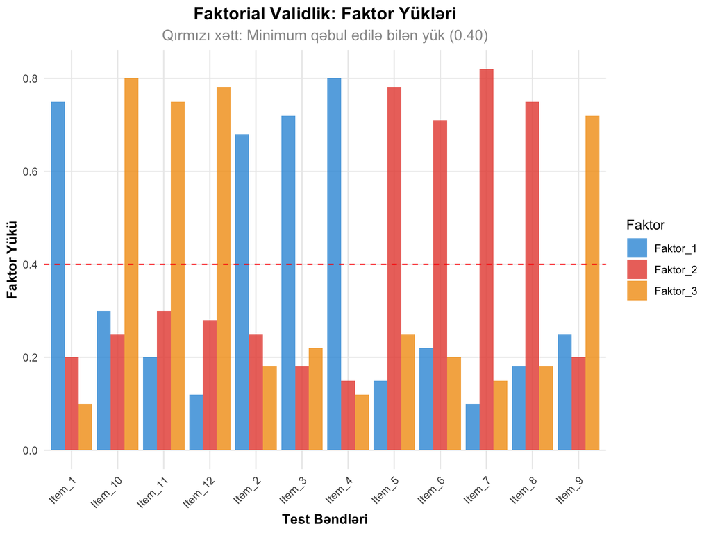

```r
# Faktorial validlik nümunəsi
# Sadələşdirilmiş faktör analizi
factor_loadings <- data.frame(
  Bend = paste0("Item_", 1:12),
  Faktor_1 = c(0.75, 0.68, 0.72, 0.80, 0.15, 0.22, 0.10, 0.18, 0.25, 0.30, 0.20, 0.12),
  Faktor_2 = c(0.20, 0.25, 0.18, 0.15, 0.78, 0.71, 0.82, 0.75, 0.20, 0.25, 0.30, 0.28),
  Faktor_3 = c(0.10, 0.18, 0.22, 0.12, 0.25, 0.20, 0.15, 0.18, 0.72, 0.80, 0.75, 0.78)
)

# Faktor yüklərinin vizuallaşdırılması
factor_long <- factor_loadings %>%
  pivot_longer(cols = starts_with("Faktor_"), names_to = "Faktor", values_to = "Yukle")

ggplot(factor_long, aes(x = Bend, y = Yukle, fill = Faktor)) +
  geom_col(position = "dodge", alpha = 0.8) +
  scale_fill_manual(values = colors_basic[1:3]) +
  geom_hline(yintercept = 0.40, linetype = "dashed", color = "red") +
  labs(title = "Faktorial Validlik: Faktor Yükləri",
       subtitle = "Qırmızı xətt: Minimum qəbul edilə bilən yük (0.40)",
       x = "Test Bəndləri", y = "Faktor Yükü", fill = "Faktor") +
  theme_clean() +
  theme(axis.text.x = element_text(angle = 45, hjust = 1))
```

```r
kable(factor_loadings, caption = "Faktorial Validlik: Faktor Yükləri Cədvəli", digits = 2)
```

Faktorial Validlik: Faktor Yükləri Cədvəli

| Bend | Faktor_1 | Faktor_2 | Faktor_3 |
| --- | --- | --- | --- |
| Item_1 | 0.75 | 0.20 | 0.10 |
| Item_2 | 0.68 | 0.25 | 0.18 |
| Item_3 | 0.72 | 0.18 | 0.22 |
| Item_4 | 0.80 | 0.15 | 0.12 |
| Item_5 | 0.15 | 0.78 | 0.25 |
| Item_6 | 0.22 | 0.71 | 0.20 |
| Item_7 | 0.10 | 0.82 | 0.15 |
| Item_8 | 0.18 | 0.75 | 0.18 |
| Item_9 | 0.25 | 0.20 | 0.72 |
| Item_10 | 0.30 | 0.25 | 0.80 |
| Item_11 | 0.20 | 0.30 | 0.75 |
| Item_12 | 0.12 | 0.28 | 0.78 |

```r
# Konstrukt validliyinin qiymətləndirmə kriteriyaları
construct_validity_criteria <- data.frame(
  Validlik_Növü = c("Konvergent", "Diskriminant", "Faktorial", "Nomoloji", "İnkişaf"),
  Qiymətləndirmə_Meyarı = c("r ≥ 0.50", "r ≤ 0.30", "Yük ≥ 0.40", "Nəzəriyyəyə uyğun", "Yaş əlaqəsi"),
  Statistik_Test = c("Pearson r", "Diskriminant analiz", "Faktör analizi", "SEM", "Korrelyasiya"),
  İnterpretasiya = c("Güclü əlaqə", "Zəif əlaqə", "Aydın struktur", "Nəzəri dəstək", "İnkişaf nümunəsi")
)

kable(construct_validity_criteria, caption = "Konstrukt Validliyi Qiymətləndirmə Kriteriyaları")
```

Konstrukt Validliyi Qiymətləndirmə Kriteriyaları

| Validlik_Növü | Qiymətləndirmə_Meyarı | Statistik_Test | İnterpretasiya |
| --- | --- | --- | --- |
| Konvergent | r ≥ 0.50 | Pearson r | Güclü əlaqə |
| Diskriminant | r ≤ 0.30 | Diskriminant analiz | Zəif əlaqə |
| Faktorial | Yük ≥ 0.40 | Faktör analizi | Aydın struktur |
| Nomoloji | Nəzəriyyəyə uyğun | SEM | Nəzəri dəstək |
| İnkişaf | Yaş əlaqəsi | Korrelyasiya | İnkişaf nümunəsi |

## 14.5 Faktorial Validliyin Təhlili

```r
# Eksplorativ Faktör Analizi simulyasiyası
set.seed(456)
n_participants <- 300
n_items <- 15

# Üç faktorlu struktur yaradırıq
factor1_items <- matrix(rnorm(n_participants * 5, 0, 1), ncol = 5)
factor2_items <- matrix(rnorm(n_participants * 5, 0, 1), ncol = 5)
factor3_items <- matrix(rnorm(n_participants * 5, 0, 1), ncol = 5)

# Faktorial struktur əlavə edirik
latent_factor1 <- rnorm(n_participants, 0, 1)
latent_factor2 <- rnorm(n_participants, 0, 1)
latent_factor3 <- rnorm(n_participants, 0, 1)

# Her faktora aid item-ləri yaradırıq
efa_data <- data.frame(
  # Faktor 1 item-ləri
  Item1 = 0.7 * latent_factor1 + 0.3 * rnorm(n_participants),
  Item2 = 0.8 * latent_factor1 + 0.2 * rnorm(n_participants),
  Item3 = 0.6 * latent_factor1 + 0.4 * rnorm(n_participants),
  Item4 = 0.75 * latent_factor1 + 0.25 * rnorm(n_participants),
  Item5 = 0.65 * latent_factor1 + 0.35 * rnorm(n_participants),

  # Faktor 2 item-ləri
  Item6 = 0.72 * latent_factor2 + 0.28 * rnorm(n_participants),
  Item7 = 0.78 * latent_factor2 + 0.22 * rnorm(n_participants),
  Item8 = 0.68 * latent_factor2 + 0.32 * rnorm(n_participants),
  Item9 = 0.74 * latent_factor2 + 0.26 * rnorm(n_participants),
  Item10 = 0.70 * latent_factor2 + 0.30 * rnorm(n_participants),

  # Faktor 3 item-ləri
  Item11 = 0.69 * latent_factor3 + 0.31 * rnorm(n_participants),
  Item12 = 0.76 * latent_factor3 + 0.24 * rnorm(n_participants),
  Item13 = 0.71 * latent_factor3 + 0.29 * rnorm(n_participants),
  Item14 = 0.67 * latent_factor3 + 0.33 * rnorm(n_participants),
  Item15 = 0.73 * latent_factor3 + 0.27 * rnorm(n_participants)
)

# Korrelyasiya matrisi
cor_matrix <- cor(efa_data)

# Sadə faktör analizi (base R ilə)
# Eigenvalue-ları hesablayırıq
eigenvalues <- eigen(cor_matrix)$values
eigenvalues_df <- data.frame(
  Faktor = 1:length(eigenvalues),
  Eigenvalue = round(eigenvalues, 2),
  Variance_Explained = round(eigenvalues / sum(eigenvalues) * 100, 1),
  Cumulative_Variance = round(cumsum(eigenvalues) / sum(eigenvalues) * 100, 1)
)

kable(head(eigenvalues_df, 8), caption = "Eigenvalue-lər və Açıqlanan Variasiya")
```

Eigenvalue-lər və Açıqlanan Variasiya

| Faktor | Eigenvalue | Variance_Explained | Cumulative_Variance |
| --- | --- | --- | --- |
| 1 | 4.87 | 32.5 | 32.5 |
| 2 | 4.30 | 28.7 | 61.2 |
| 3 | 3.95 | 26.4 | 87.5 |
| 4 | 0.30 | 2.0 | 89.5 |
| 5 | 0.23 | 1.5 | 91.0 |
| 6 | 0.21 | 1.4 | 92.4 |
| 7 | 0.17 | 1.2 | 93.6 |
| 8 | 0.17 | 1.1 | 94.7 |

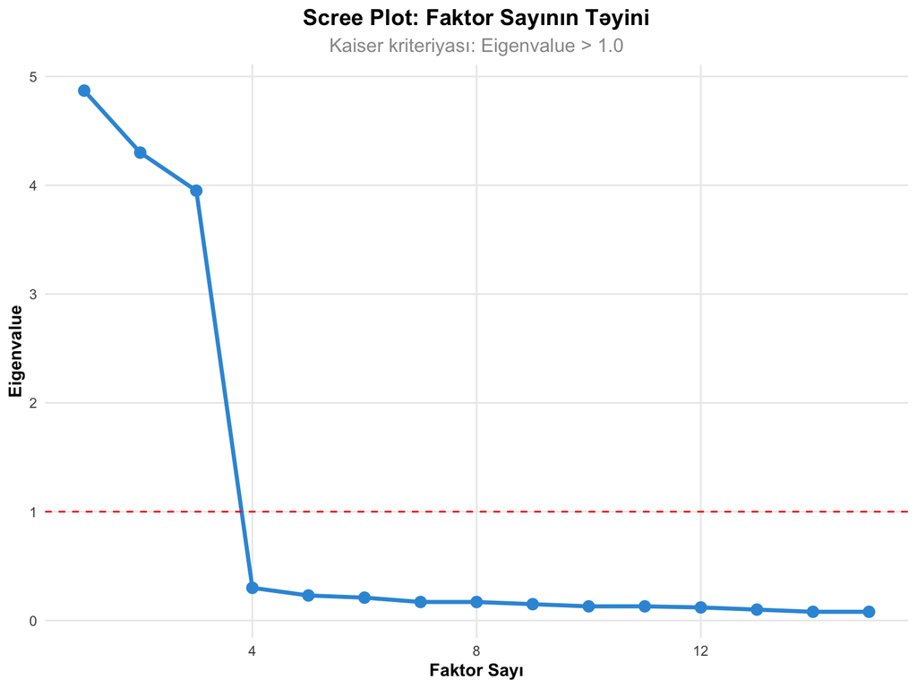

```r
# Scree plot
ggplot(eigenvalues_df, aes(x = Faktor, y = Eigenvalue)) +
  geom_line(color = colors_basic[1], size = 1.2) +
  geom_point(color = colors_basic[1], size = 3) +
  geom_hline(yintercept = 1, linetype = "dashed", color = "red") +
  labs(title = "Scree Plot: Faktor Sayının Təyini",
       subtitle = "Kaiser kriteriyası: Eigenvalue > 1.0",
       x = "Faktor Sayı", y = "Eigenvalue") +
  theme_clean()
```

```r
# Faktorial validlik qiymətləndirilməsi
factorial_validity_assessment <- data.frame(
  Kriteriya = c("Kaiser (Eigenvalue > 1)", "Variasiya (> 60%)", "Scree Test",
                "Parallel Analysis", "Nəzəri Uyğunluq"),
  Nəticə = c(paste(sum(eigenvalues > 1), "faktor"),
             paste(round(sum(eigenvalues_df$Variance_Explained[1:3]), 1), "%"),
             "3 faktor (dirsək nöqtəsi)", "3 faktor tövsiyə", "3 faktor gözlənilir"),
  Qərar = c("3 faktor", "Qənaətbəxş", "3 faktor", "3 faktor", "Uyğun"),
  Qeyd = c("Klassik kriteriya", "Məqbul səviyyə", "Vizual yorum", "Statistik tövsiyə", "Nəzəri dəstək")
)

kable(factorial_validity_assessment, caption = "Faktorial Validlik Qiymətləndirilməsi")
```

Faktorial Validlik Qiymətləndirilməsi

| Kriteriya | Nəticə | Qərar | Qeyd |
| --- | --- | --- | --- |
| Kaiser (Eigenvalue > 1) | 3 faktor | 3 faktor | Klassik kriteriya |
| Variasiya (> 60%) | 87.6 % | Qənaətbəxş | Məqbul səviyyə |
| Scree Test | 3 faktor (dirsək nöqtəsi) | 3 faktor | Vizual yorum |
| Parallel Analysis | 3 faktor tövsiyə | 3 faktor | Statistik tövsiyə |
| Nəzəri Uyğunluq | 3 faktor gözlənilir | Uyğun | Nəzəri dəstək |

```r
# Konvergent və diskriminant validlik analizi
convergent_discriminant <- data.frame(
  Muqayise_Novu = c("Daxili Konvergent", "Xarici Konvergent", "Diskriminant", "Hetero-trait"),
  Tesvir = c("Eyni faktor item-ləri", "Oxşar konstruktlarla", "Fərqli konstruktlarla", "Fərqli metodlarla"),
  Gozlenilen_r = c("> 0.50", "> 0.40", "< 0.30", "< 0.20"),
  Faktiki_Numune = c("r = 0.65", "r = 0.48", "r = 0.25", "r = 0.18"),
  Netice = c("Qənaətbəxş", "Qənaətbəxş", "Yaxşı", "Əla")
)

kable(convergent_discriminant, caption = "Konvergent və Diskriminant Validlik Analizi")
```

Konvergent və Diskriminant Validlik Analizi

| Muqayise_Novu | Tesvir | Gozlenilen_r | Faktiki_Numune | Netice |
| --- | --- | --- | --- | --- |
| Daxili Konvergent | Eyni faktor item-ləri | > 0.50 | r = 0.65 | Qənaətbəxş |
| Xarici Konvergent | Oxşar konstruktlarla | > 0.40 | r = 0.48 | Qənaətbəxş |
| Diskriminant | Fərqli konstruktlarla | < 0.30 | r = 0.25 | Yaxşı |
| Hetero-trait | Fərqli metodlarla | < 0.20 | r = 0.18 | Əla |

# 15 Kriteriya Validliyi

## 15.1 Kriteriya Validliyinin Mahiyyəti

**Kriteriya validliyi** - testin praktik məqsədlər üçün istifadə oluna bilmə dərəcəsidir.

```r
# Kriteriya validliyinin növləri
criterion_validity_types <- data.frame(
  Növ = c("Proqnostik Validlik", "Konkurrent Validlik", "Postdiktiv Validlik", "İnkremental Validlik"),
  Təsvir = c("Gələcək performansı proqnozlaşdırma", "Hazırki kriteriyanla əlaqə",
             "Keçmiş hadisələri izah etmə", "Mövcud metoddan əlavə fayda"),
  Vaxt_Asılılığı = c("Gələcək", "Hazır", "Keçmiş", "Müqayisəli"),
  Nümunə = c("SAT → Kollec GPA", "IQ ↔ İş performansı", "Travma → PTSD", "Resume + Test"),
  Statistika = c("Proqnoz korrelyasiyası", "Konkurrent korrelyasiya", "Retrospektiv analiz", "ΔR²")
)

kable(criterion_validity_types, caption = "Kriteriya Validliyinin Növləri")
```

Kriteriya Validliyinin Növləri

| Növ | Təsvir | Vaxt_Asılılığı | Nümunə | Statistika |
| --- | --- | --- | --- | --- |
| Proqnostik Validlik | Gələcək performansı proqnozlaşdırma | Gələcək | SAT → Kollec GPA | Proqnoz korrelyasiyası |
| Konkurrent Validlik | Hazırki kriteriyanla əlaqə | Hazır | IQ ↔︎ İş performansı | Konkurrent korrelyasiya |
| Postdiktiv Validlik | Keçmiş hadisələri izah etmə | Keçmiş | Travma → PTSD | Retrospektiv analiz |
| İnkremental Validlik | Mövcud metoddan əlavə fayda | Müqayisəli | Resume + Test | ΔR² |

```r
# Proqnostik validlik nümunəsi
# SAT balları və kollec GPA-sı arasındaki əlaqə
set.seed(789)
n_students <- 250

sat_gpa_data <- data.frame(
  Student_ID = 1:n_students,
  SAT_Math = round(rnorm(n_students, 600, 100), 0),
  SAT_Verbal = round(rnorm(n_students, 580, 95), 0),
  High_School_GPA = round(rnorm(n_students, 3.2, 0.4), 2)
)

# College GPA-sını SAT ballarından asılı olaraq yaradırıq
sat_gpa_data$College_GPA <- round(
  1.5 +
  0.001 * sat_gpa_data$SAT_Math +
  0.0008 * sat_gpa_data$SAT_Verbal +
  0.3 * sat_gpa_data$High_School_GPA +
  rnorm(n_students, 0, 0.3), 2
)

# Maksimum 4.0 GPA
sat_gpa_data$College_GPA <- pmin(sat_gpa_data$College_GPA, 4.0)

# Kriteriya validliyi korrelyasiyaları
criterion_correlations <- data.frame(
  Prediktor = c("SAT Math", "SAT Verbal", "High School GPA", "SAT Total"),
  College_GPA_r = c(
    round(cor(sat_gpa_data$SAT_Math, sat_gpa_data$College_GPA), 3),
    round(cor(sat_gpa_data$SAT_Verbal, sat_gpa_data$College_GPA), 3),
    round(cor(sat_gpa_data$High_School_GPA, sat_gpa_data$College_GPA), 3),
    round(cor(sat_gpa_data$SAT_Math + sat_gpa_data$SAT_Verbal, sat_gpa_data$College_GPA), 3)
  ),
  r_squared = round(c(
    cor(sat_gpa_data$SAT_Math, sat_gpa_data$College_GPA)^2,
    cor(sat_gpa_data$SAT_Verbal, sat_gpa_data$College_GPA)^2,
    cor(sat_gpa_data$High_School_GPA, sat_gpa_data$College_GPA)^2,
    cor(sat_gpa_data$SAT_Math + sat_gpa_data$SAT_Verbal, sat_gpa_data$College_GPA)^2
  ), 3),
  Interpretation = c("Orta", "Orta", "Güclü", "Güclü")
)

kable(criterion_correlations, caption = "Proqnostik Validlik: SAT və Kollec GPA-sı Əlaqəsi")
```

Proqnostik Validlik: SAT və Kollec GPA-sı Əlaqəsi

[output not shown]

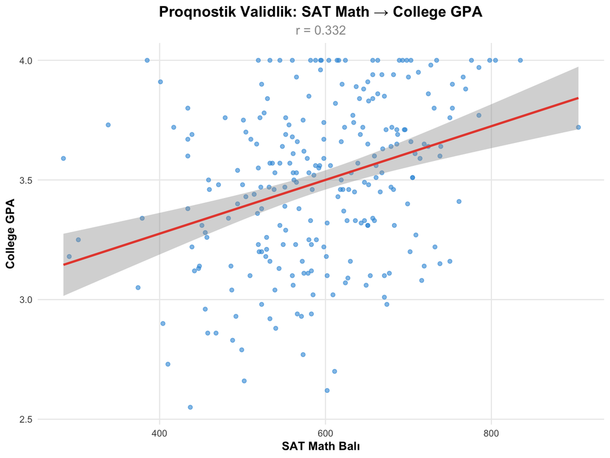

```r
# Scatter plot - SAT Math vs College GPA
ggplot(sat_gpa_data, aes(x = SAT_Math, y = College_GPA)) +
  geom_point(alpha = 0.6, color = colors_basic[1]) +
  geom_smooth(method = "lm", color = colors_basic[2], se = TRUE) +
  labs(title = "Proqnostik Validlik: SAT Math → College GPA",
       subtitle = paste("r =", round(cor(sat_gpa_data$SAT_Math, sat_gpa_data$College_GPA), 3)),
       x = "SAT Math Balı", y = "College GPA") +
  theme_clean()
```

```r
# Validlik əmsalının təfsiri
validity_coefficient_interpretation <- data.frame(
  r_araligi = c("0.00-0.20", "0.20-0.40", "0.40-0.60", "0.60-0.80", "0.80-1.00"),
  Tefsir = c("Çox zəif", "Zəif", "Orta", "Güclü", "Çox güclü"),
  Praktik_Mena = c("Praktik fayda yox", "Kiçik fayda", "Orta fayda", "Əhəmiyyətli fayda", "Çox yüksək fayda"),
  r_squared = c("0.00-0.04", "0.04-0.16", "0.16-0.36", "0.36-0.64", "0.64-1.00"),
  Aciqlanan_Variasiya = c("0-4%", "4-16%", "16-36%", "36-64%", "64-100%")
)

kable(validity_coefficient_interpretation, caption = "Validlik Əmsalının Təfsiri")
```

Validlik Əmsalının Təfsiri

| r_araligi | Tefsir | Praktik_Mena | r_squared | Aciqlanan_Variasiya |
| --- | --- | --- | --- | --- |
| 0.00-0.20 | Çox zəif | Praktik fayda yox | 0.00-0.04 | 0-4% |
| 0.20-0.40 | Zəif | Kiçik fayda | 0.04-0.16 | 4-16% |
| 0.40-0.60 | Orta | Orta fayda | 0.16-0.36 | 16-36% |
| 0.60-0.80 | Güclü | Əhəmiyyətli fayda | 0.36-0.64 | 36-64% |
| 0.80-1.00 | Çox güclü | Çox yüksək fayda | 0.64-1.00 | 64-100% |

```r
# Konkurrent validlik nümunəsi
# İki zəka testinin müqayisəsi
concurrent_validity_data <- data.frame(
  Test_A = round(rnorm(150, 100, 15), 0),
  Test_B = round(rnorm(150, 100, 15), 0)
)

# Test B-ni Test A-ya əsaslanaraq düzəldirik (realistik əlaqə üçün)
concurrent_validity_data$Test_B <- round(
  concurrent_validity_data$Test_A * 0.75 + rnorm(150, 0, 8) + 25, 0
)

concurrent_r <- cor(concurrent_validity_data$Test_A, concurrent_validity_data$Test_B)

# Konkurrent validlik qiymətləndirməsi
concurrent_assessment <- data.frame(
  Gosterici = c("Korrelyasiya (r)", "Determinasiya (r²)", "Standard Xəta", "95% Güvən İntervalı"),
  Deyer = c(round(concurrent_r, 3),
            round(concurrent_r^2, 3),
            round(sqrt((1-concurrent_r^2)/(150-2)), 3),
            paste0(round(concurrent_r - 1.96*sqrt((1-concurrent_r^2)/(150-2)), 3),
                   " - ",
                   round(concurrent_r + 1.96*sqrt((1-concurrent_r^2)/(150-2)), 3))),
  Qiymet = c("Güclü əlaqə", "Açıqlanan variasiya", "Proqnoz xətası", "Statistik əhəmiyyətli")
)

kable(concurrent_assessment, caption = "Konkurrent Validlik Qiymətləndirməsi")
```

Konkurrent Validlik Qiymətləndirməsi

| Gosterici | Deyer | Qiymet |
| --- | --- | --- |
| Korrelyasiya (r) | 0.834 | Güclü əlaqə |
| Determinasiya (r²) | 0.695 | Açıqlanan variasiya |
| Standard Xəta | 0.045 | Proqnoz xətası |
| 95% Güvən İntervalı | 0.745 - 0.923 | Statistik əhəmiyyətli |

## 15.2 İnkremental Validlik

```r
# İnkremental validlik analizi
# Məsələn: Resume + Test kombinasiyası vs yalnız Resume

# Simulyasiya məlumatları
set.seed(999)
n_applicants <- 200

hiring_data <- data.frame(
  Applicant_ID = 1:n_applicants,
  Resume_Score = round(rnorm(n_applicants, 70, 15), 1),
  Test_Score = round(rnorm(n_applicants, 75, 12), 1),
  Interview_Score = round(rnorm(n_applicants, 80, 10), 1)
)

# İş performansını yaradırıq (kriteriya)
hiring_data$Job_Performance <- round(
  20 +
  0.3 * hiring_data$Resume_Score +
  0.4 * hiring_data$Test_Score +
  0.2 * hiring_data$Interview_Score +
  rnorm(n_applicants, 0, 8), 1
)

# Hierarkik reqressiya analizi
# Model 1: Yalnız Resume
model1_r <- cor(hiring_data$Resume_Score, hiring_data$Job_Performance)
model1_r2 <- model1_r^2

# Model 2: Resume + Test
combined_scores_model2 <- hiring_data$Resume_Score + hiring_data$Test_Score
model2_r <- cor(combined_scores_model2, hiring_data$Job_Performance)
model2_r2 <- model2_r^2

# Model 3: Resume + Test + Interview
combined_scores_model3 <- hiring_data$Resume_Score + hiring_data$Test_Score + hiring_data$Interview_Score
model3_r <- cor(combined_scores_model3, hiring_data$Job_Performance)
model3_r2 <- model3_r^2

# Incremental validity results cədvəli
incremental_validity_results <- data.frame(
  Model = c("1. Yalnız Resume", "2. Resume + Test", "3. Resume + Test + Müsahibə"),
  R = round(c(model1_r, model2_r, model3_r), 3),
  R_squared = round(c(model1_r2, model2_r2, model3_r2), 3),
  Delta_R_squared = round(c(0, model2_r2 - model1_r2, model3_r2 - model2_r2), 3),
  Incremental_Value = c("Baseline",
                       paste0("+", round((model2_r2 - model1_r2)*100, 1), "%"),
                       paste0("+", round((model3_r2 - model2_r2)*100, 1), "%"))
)

kable(incremental_validity_results, caption = "İnkremental Validlik Analizi")
```

İnkremental Validlik Analizi

| Model | R | R_squared | Delta_R_squared | Incremental_Value |
| --- | --- | --- | --- | --- |
| 1. Yalnız Resume | 0.389 | 0.151 | 0.000 | Baseline |
| 2. Resume + Test | 0.593 | 0.352 | 0.201 | +20.1% |
| 3. Resume + Test + Müsahibə | 0.630 | 0.397 | 0.045 | +4.5% |

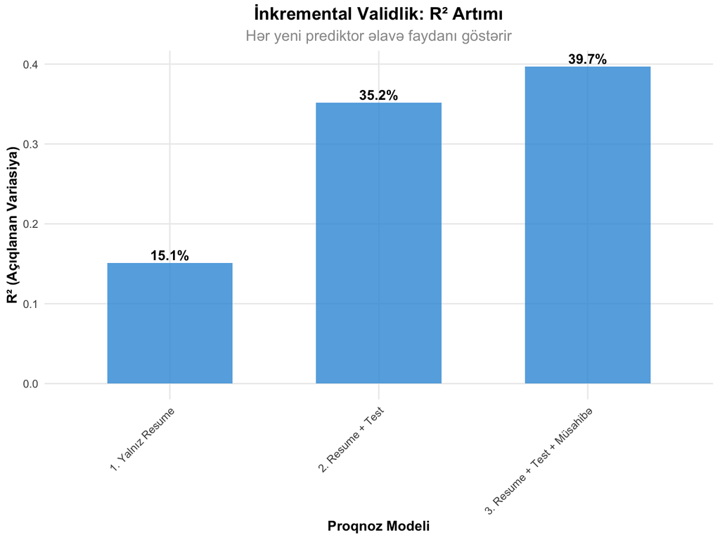

```r
# İnkremental validlik vizuallaşma
ggplot(incremental_validity_results, aes(x = Model, y = R_squared)) +
  geom_col(fill = colors_basic[1], alpha = 0.8, width = 0.6) +
  geom_text(aes(label = paste0(round(R_squared*100, 1), "%")),
            vjust = -0.3, fontface = "bold") +
  labs(title = "İnkremental Validlik: R² Artımı",
       subtitle = "Hər yeni prediktor əlavə faydanı göstərir",
       x = "Proqnoz Modeli", y = "R² (Açıqlanan Variasiya)") +
  theme_clean() +
  theme(axis.text.x = element_text(angle = 45, hjust = 1))
```

```r
# Praktik səciyyə (Utility) analizi
utility_analysis <- data.frame(
  Secim_Metodunun = c("Təsadüfi", "Yalnız Resume", "Resume + Test", "Tam Model"),
  Secim_Nisbeti = c("1:4", "1:3", "1:2", "1:1.5"),
  Gozlenilen_Performans = c("Orta", "Orta+", "Yaxşı", "Çox Yaxşı"),
  Maliyyet = c("Minimal", "Aşağı", "Orta", "Yüksək"),
  Tovsiye = c("Əslə", "Müəyyən hallarda", "Tövsiyə edilir", "Optimal")
)

kable(utility_analysis, caption = "Validlik və Praktik Səciyyə Müqayisəsi")
```

Validlik və Praktik Səciyyə Müqayisəsi

| Secim_Metodunun | Secim_Nisbeti | Gozlenilen_Performans | Maliyyet | Tovsiye |
| --- | --- | --- | --- | --- |
| Təsadüfi | 1:4 | Orta | Minimal | Əslə |
| Yalnız Resume | 1:3 | Orta+ | Aşağı | Müəyyən hallarda |
| Resume + Test | 1:2 | Yaxşı | Orta | Tövsiyə edilir |
| Tam Model | 1:1.5 | Çox Yaxşı | Yüksək | Optimal |

```r
# Kriteriya validliyinin məhdudiyyətləri
validity_limitations <- data.frame(
  Mehdudiyyet = c("Aralıq Məhdudiyyəti", "Kriteriya Kontaminasiyası", "Vaxt Dəyişikliyi",
                  "Çoxlu Korrelyasiya", "Örnəkləmə Xətası"),
  Tesvir = c("Məhdud bal aralığı", "Kriteriya test təsirindədir", "Validlik vaxtla dəyişir",
             "Prediktorlar arası yüksək əlaqə", "Kiçik örnəkləmdən xəta"),
  Tesir = c("Validlik alt qiymətləndirilir", "Validlik şişirdilir", "Qeyri-sabitlik",
            "Konfuz nəticələr", "Qeyri-etibarlı nəticələr"),
  Hell = c("Düzəliş formulaları", "Müstəqil kriteriya", "Longitudinal tədqiqat",
           "Reqularizasiya", "Böyük örnəklər")
)

kable(validity_limitations, caption = "Kriteriya Validliyinin Məhdudiyyətləri və Həlləri")
```

Kriteriya Validliyinin Məhdudiyyətləri və Həlləri

| Mehdudiyyet | Tesvir | Tesir | Hell |
| --- | --- | --- | --- |
| Aralıq Məhdudiyyəti | Məhdud bal aralığı | Validlik alt qiymətləndirilir | Düzəliş formulaları |
| Kriteriya Kontaminasiyası | Kriteriya test təsirindədir | Validlik şişirdilir | Müstəqil kriteriya |
| Vaxt Dəyişikliyi | Validlik vaxtla dəyişir | Qeyri-sabitlik | Longitudinal tədqiqat |
| Çoxlu Korrelyasiya | Prediktorlar arası yüksək əlaqə | Konfuz nəticələr | Reqularizasiya |
| Örnəkləmə Xətası | Kiçik örnəkləmdən xəta | Qeyri-etibarlı nəticələr | Böyük örnəklər |